# Les effets du travail en groupe

Baptiste VIOLA, Baptiste NEPVEUX et Mohamed BALDE

# 1 INTRODUCTION

Le travail effectué porte sur une base de donnée qui présente un questionnaire assez général sur la licence d’économie à Tours, ce questionnaire a été réalisé par des élèves de troisième année de l’année 2019/2020. Il présente les résultats de 146 individus et contient 40 variables. Parmi les 146 répondants, il y a 70 L1, 36 L2 et 40 L3. De plus, les réponses aux variables concernant les notes n’ont été obtenues que par des étudiants de première année, ceci correspond à 52 répondants sur 146. Notre projet repose principalement sur l’étude de la variable “Travail en groupe” et de tout ce qui gravite autour en terme d’analyse statistique.

**PROBLEMATIQUE :** Nous nous demanderons quels sont les différents effets du travail en groupe, et si le fait de plus ou moins travailler en groupe a une association statistiquement significative sur d’autres variables.

*Mise en garde* : Les tests effectués et les analyses tirées de nos travaux se basent sur un nombre réduit d’observation et sur des réponses au questionnaire qui ont peut-être parfois été blâclées par certains répondants qui n’avaient pas d’idée de réponse ou qui étaient préssés que le questionnaire se termine. Il s’agira donc d’être méfiant et d’avoir un regard critique sur les interprétations.

# 2 Présentation de la variable etudiée principalement : Le travail en groupe

[interactive chart not shown]

On voit donc grâce à ces observations qu’il y a 30 personnes qui travaillent très souvent en groupe, 60 personnes qui travaillent parfois en groupe, 39 personnes qui travaillent peu en groupe et enfin 17 personnes qui ne travaillent pas du tout en groupe.

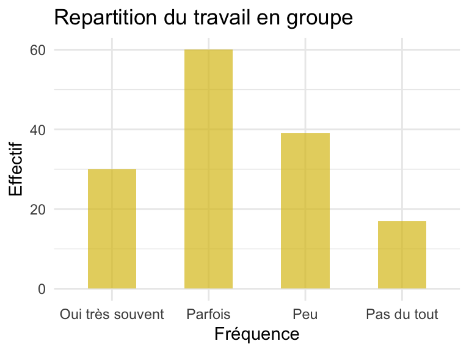

# 3 Le travail en groupe / genre

## 3.1 Observation

Une première piste d’étude serait d’abord de voir s’il y a une certaine tendance à travailler en groupe ou non en fonction du sexe des répondants.Avant tout, nous avons besoin de connaitre les proportions respectives d’hommes et de femmes qui ont répondu à ce questionnaire. Il y 81 hommes et 65 femmes qui ont répondu au questionnaire. En proportion cela fait 55.5% des réponses par des hommes et 44.5% des réponses par des femmes. On observe donc que les proportions sont à peu près égales.

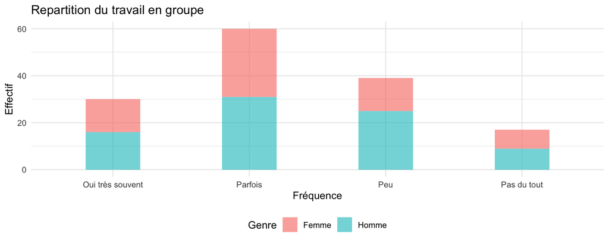

Ce graphique permet de voir la proportion de femmes et d’hommes dans chaque modalité du travail en groupe. Comparons de plus près les différences d’effectifs :

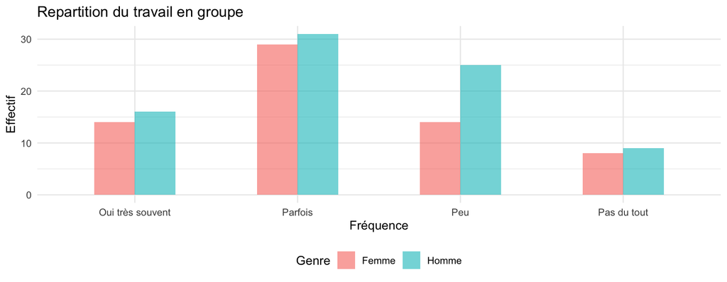

On observe à priori sur ce graphique qu’il n’y a pas de différence majeure entre le fait par exemple qu’il y ait beaucoup plus d’hommes que de femmes qui travaillent en groupe et vice versa (hormis peut-être pour la modalité “Peu”); Ces deux variables (genre et travail en groupe) pourraient être liées si par exemple on observait qu’une proportion d’un sexe travaillait significativement plus en groupe qu’un autre. Vérifions cela correctement grâce à un test du Khi deux.

### 3.1.1 Test d’indépendance du Khi deux

| Résultats du test du Khi-deux Eff att min | Résultats du test du Khi-deux p.value | Résultats du test du Khi-deux Contribution max |
| --- | --- | --- |
| 7.57 | 0.65 | 0.72 |

D’après le résultat ci-dessus, nous conservons l’hypothèse nulle d’indépendance des variables (la p-value est élevée), c’est-à-dire qu’il n’y a pas un sexe qui travaille plus que l’autre en groupe.

# 4 Le travail en groupe / Plaisir pour les cours

Tout d’abord, parmi l’ensemble de la licence, il y a 106 personnes qui aiment leurs cours, 39 personnes qui n’aiment pas plus que ça leurs cours et 1 personne qui n’aime pas ses cours.

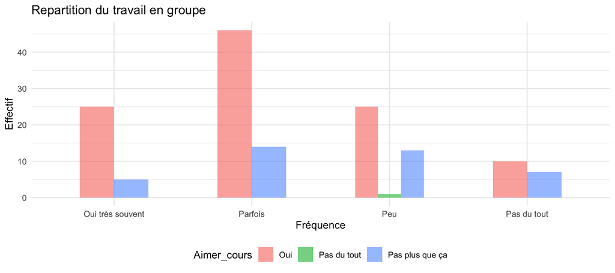

Le nombre d’étudiants ayant repondu “Pas plus que ca” étant très élevé alors que le nombre d’étudiants ayant répondu “Pas du tout” ne s’élève qu’à 1, il parait raisonnable de regrouper ces deux modalités sous le nom de “Non”.

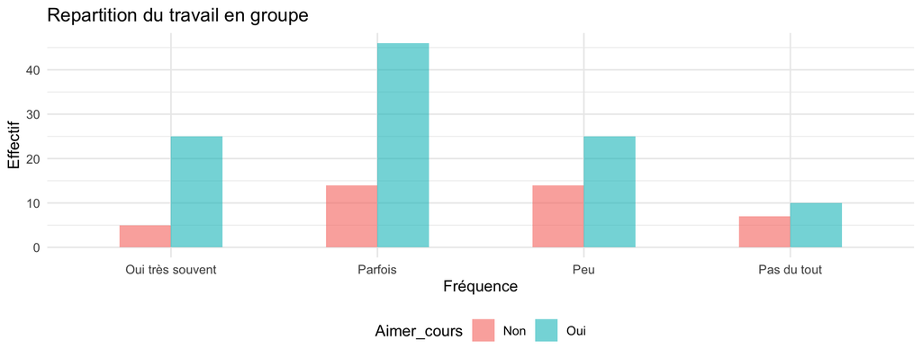

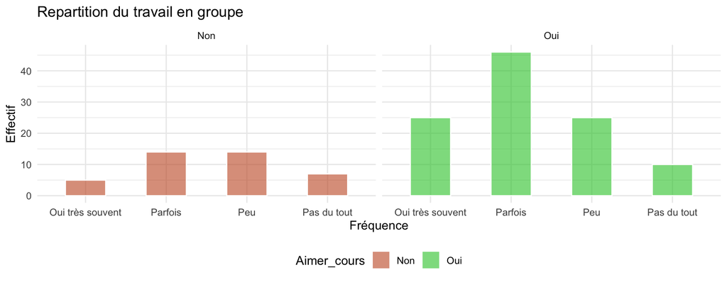

On observe qu’il y a une petite tendance pour les étudiants à plus travailler en groupe lorsque qu’ils aiment les cours.

Résultats du test d’indépendance du Khi deux :

| Résultats du test du Khi-deux Eff att min | Résultats du test du Khi-deux p.value | Résultats du test du Khi-deux Contribution max |
| --- | --- | --- |
| 4.66 | 0.15 | 0.73 |

Les effectifs de la valeur “pas du tout” étant trop petits, il faut ajouter cette ligne avec la ligne de la modalité “Peu”.

| Résultats du test du Khi-deux Eff att min | Résultats du test du Khi-deux p.value | Résultats du test du Khi-deux Contribution max |
| --- | --- | --- |
| 8.22 | 0.08 | 0.73 |

Au risque de première espèce de 10%, les deux variables ne sont pas significativement indépendantes, ce qui signifie qu’il y a une certaine influence entre ces deux variables et que le fait de travailler en groupe ou non peut être lié au fait de plus ou moins aimer les cours. Ici nous rejetons donc l’hypothèse nulle, pour savoir s’il n’y a pas une modalité qui contribue de manière excessive à la valeur du Khi-deux et donc au rejet de H0, nous devons nous pencher sur l’étude des contributions au Khi-deux. Le tableau ci-dessus nous révèle que la contribution maximale observée pour une modalité est de 72.6%, ce qui est très élevé. Une étude en détail nous a montré que cela correspondait à la colonne “Non” du tableau permettant de faire le test. Par conséquent nous devrions voir ce que le test retourne si nous supprimions cette valeur du test mais cela ne serait pas pertinent puisqu’il ne resterait qu’une valeur sur les deux à savoir “Oui”. Et cette contribution élevée n’est peut-être anodine puisqu’il n’y a justement que deux modalités (Oui / Non) possibles pour cette variable.

# 5 Le travail en groupe / Année d’étude

## 5.1 Observation du niveau de travail en groupe/ année d’étude

|  | L1 | L2 | L3 |
| --- | --- | --- | --- |
| Oui très souvent | 12 | 8 | 10 |
| Parfois | 27 | 15 | 18 |
| Peu | 20 | 9 | 10 |
| Pas du tout | 11 | 4 | 2 |

On observe a priori avec ce tableau qu’il n’y a pas l’air d’y avoir une tendance à l’augmentation des proportions relatives à travailler en groupe année après année pour les étudiants.

## 5.2 Test d’indépendance du Khi-deux

| Résultats du test du Khi-deux Eff att min | Résultats du test du Khi-deux p.value | Résultats du test du Khi-deux Contribution max |
| --- | --- | --- |
| 4.19 | 0.71 | 0.55 |

On s’apperçoit que les effectifs attendus pour la modalité “Pas du tout” ne sont pas supérieurs à 5, et par conséquent que l’approximation au Khi deux n’est pas correcte, on doit donc regrouper les modalités “Peu” et “Pas du tout”.

| Résultats du test du Khi-deux Eff att min | Résultats du test du Khi-deux p.value | Résultats du test du Khi-deux Contribution max |
| --- | --- | --- |
| 7.4 | 0.64 | 0.5 |

La p-value étant très élevée, on conclut qu’il n’y a pas de lien entre le fait d’être en L1, L2 ou L3 et le fait de plus ou moins travailler en groupe. Ces deux variables sont indépendantes, on conserve l’hypothèse nulle. Ceci est peut-être contre intuitif car on pourrait penser de prime abord que la proportion d’étudiants travaillant en groupe augmenterait en fonction de l’année d’étude, du fait de la réduction année après année de la promotion et que les gens se connaissent de mieux en mieux. Mais rappelons que nous avons un nombre réduit de répondants par rapport à l’ensemble de la licence.

# 6 Le travail en groupe/ Les notes

Tout d’abord, cette partie ne va concerner que les étudiants en première année car ce sont les seuls qui ont communiqué leurs notes dans les différentes matières, ce qui réduit un peu plus le nombre de répondants, et par conséquent rendra l’analyse plus délicate à interpréter. Pour rappel, il y 52 répondants pour les variables concernant les notes, donc notre analyse se base sur 52 personnes.

La corrélation travail en groupe/notes :

Cette corrélation parait pertinente à étudier car elle permet de mettre en évidence un effet concret du travail en groupe, et de pourquoi pas, permettre d’améliorer le programme en y apportant plus de travail en groupe lorsque cela est bénéfique.

## 6.1 Les étudiants travaillant en groupe ont-ils une meilleure moyenne générale?

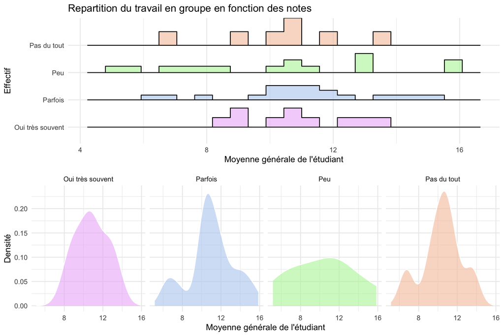

Grâce à ces deux premiers graphiques, on peut observer que les moyennes générales des étudiants qui travaillent soit “très souvent en groupe”, soit “Pas du tout en groupe” ou “Parfois en groupe” sont assez concentrées autour de la moyenne générale de l’ensemble des répondants qui est de 10.68. Pour les personnes qui travaillent peu en groupe, la répartition des moyennes générales est plus étendue. Le graphique représentant les densités permet d’ajouter à l’analyse que pour chaque fréquence du travail en groupe, les moyennes des moyennes générale de chaque étudiant sont assez similaires.Et ces moyennes pour chaque modalité du travail en groupe sont quasiment égales à la moyenne générale de l’ensemble des répondants.

Comparaison des résultats sur l’année par habitude de Travail

| Travail en Groupe | Moyenne Note | Écart type Note |
| --- | --- | --- |
| Oui très souvent | 10.81 | 1.68 |
| Parfois | 11.01 | 2.36 |
| Peu | 10.29 | 3.35 |
| Pas du tout | 10.39 | 2.12 |

Enfin, toutes ces informations peuvent être observées dans un graphique plus élaboré permettant de voir exactement pour chaque modalité du travail en groupe, l’étendue des moyennes générales, la concentration des moyennes autour d’une valeur, les premiers, deuxièmes, et troisièmes quartiles. Ce graphique de synthèse est le suivant :

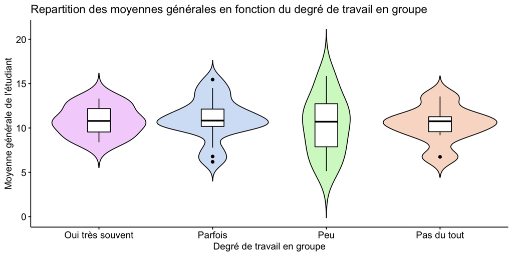

### 6.1.1 Test de Student

Avant de se lancer dans un test de Student, quelques règles sont à respecter pour valider les conditions de réalisation du test. Il est bienvenu en général d’avoir un nombre de réalisation supérieur à 30, ceci est le cas car il y a 52 répondants. Ensuite il est préférable que la distribution soit gaussienne pour faciliter les approximations à une loi normale, ceci est aussi le cas, on peut facilement l’observer avec ce simple graphique :

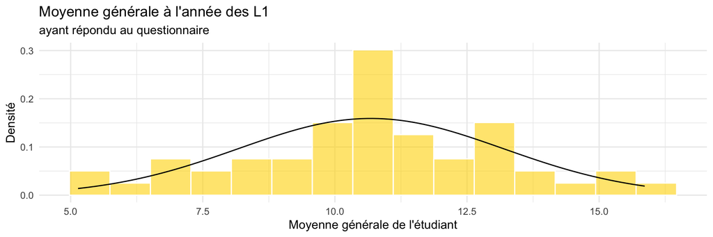

Cela se vérifie plus concrètement à l’aide d’un test de normalité :

| Résultats du test Shapiro p.value |
| --- |
| 0.55 |

La p-value étant très élevée, on peut conclure que la distribution des moyennes générales à l’année suit une distribution normale. Enfin pour effectuer un test de Student sur deux échantillons pour comparer leur moyenne, nous avons besoin de conclure à l’égalité des variances grâce au test de Fisher. Il va suivre un grand nombre de tests, pour faciliter la lisibilité des résultats, une fonction a été créée pour automatiser les résultats à la fois du test d’égalité des variances, et du résultat de la p-value issue du test de Student afin de conclure.

| Egalité des Variances | Résultats du test de Student Moyenne de x | Résultats du test de Student Moyenne de y | Résultats du test de Student p.value du t.test |
| --- | --- | --- | --- |
| Oui | 10.94 | 10.32 | 0.19 |

Après comparaison des moyennes générales des élèves ayant travaillé en groupe “Parfois”, ou “très souvent”, et des moyennes des élèves ayant travaillé en groupe “Peu” ou “Pas du tout”, il apparaît que la moyenne des élèves qui ont travaillé en groupe n’est pas significativement plus élevée que celle des autres élèves. En effet la p-value est supérieure aux différents seuils de 5 ou 10% qui nous auraient permis de rejeter l’hypothèse nulle d’égalité des moyennes des deux groupes étudiés si celle-ci avait été inférieure. Or comme elle est supérieure, nous devons conserver cette hypothèse nulle.

On effectue un réarrangement de la population en regroupant d’une part ceux qui travaillent très souvent en groupe, et d’autre part le reste des élèves.

| Egalité des Variances | Résultats du test de Student Moyenne de x | Résultats du test de Student Moyenne de y | Résultats du test de Student p.value du t.test |
| --- | --- | --- | --- |
| Oui | 10.81 | 10.65 | 0.43 |

De même lorsque l’on réarrange les groupes, on ne voit pas de différences significatives (de supériorité, test unilatéral) entre la population qui travaille très souvent en groupe et le reste.

Peut-être y a-t-il une différence entre les deux extrêmes? Vérifions cela :

| Egalité des Variances | Résultats du test de Student Moyenne de x | Résultats du test de Student Moyenne de y | Résultats du test de Student p.value du t.test |
| --- | --- | --- | --- |
| Oui | 10.81 | 10.39 | 0.33 |

Même conclusion, il n’y a pas différence de moyenne entre les personnes travaillant très souvent en groupe et celles qui ne travaillent jamais en groupe. C’est-à-dire que la moyenne des moyennes générales des deux populations pour chacun de ces tests n’est significativement pas différente, on peut conclure que travailler en groupe n’augmente pas la moyenne générale de l’étudiant. Mais prudence, nous n’avons que les moyennes générales de 52 élèves de première année.

## 6.2 Le travail en groupe est-il bénéfique dans une matière spécifique?

Les relevés des impressions ayant été faits à un instant t, sur des L1, on ne prendra donc en compte que la moyenne des deux semestres, par matière et non les notes de chaque semestre une par une.

### 6.2.1 Le cas de l’anglais

Comme pour les moyennes générales des étudiants, il est possible de représenter la distribution des moyennes d’anglais à l’année en fonction du degré de travail en groupe :

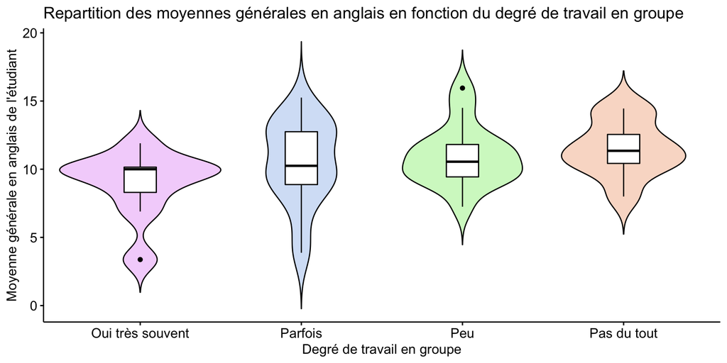

On observe sur ce graphique que les personnes ne travaillant pas en groupe du tout semblent obtenir de meilleurs résultats que ceux qui travaillent en groupe! vérifions cela avec un test de Student :

| Egalité des Variances | Résultats du test de Student Moyenne de x | Résultats du test de Student Moyenne de y | Résultats du test de Student p.value du t.test |
| --- | --- | --- | --- |
| Oui | 8.9 | 11.51 | 0.01 |

La p-value étant très faible, on rejette l’hypothèse nulle et on conclut que la moyenne des moyennes d’anglais à l’année est significativement inférieure pour les personnes qui travaillent très souvent en groupe. Cependant, la variable mesurant le degré de travail en groupe des étudiants est assez générale, en effet cette variable n’est pas spécifique à une matière en particulier, et c’est plus “en général” que les étudiants ont répondu à cette question et pas matière par matière. Cela est donc plus pertinent de l’observer sur la moyenne générale à l’année comme nous l’avons fait précedemment, mais cela reste très intéressant comme dans ce cas précis de faire des observations spécifiques à une matière donnée.

### 6.2.2 Cas des maths

Voici une représentation de la distribution des notes en Maths en fonction du degré de travail en groupe :

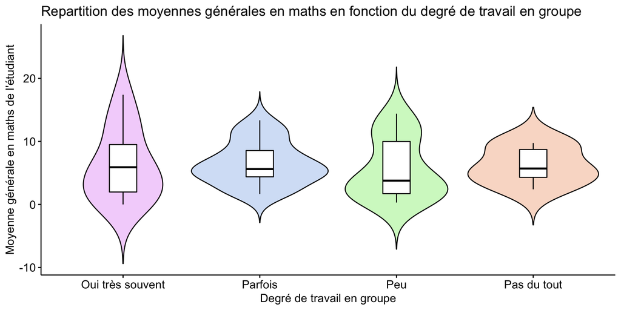

Effectuons le test associé de Student pour voir si la moyenne générale en maths de ceux qui travaillent très souvent en groupe est significativement différente de celle des étudiants qui ne travaillent pas en groupe :

| Egalité des Variances | Résultats du test de Student Moyenne de x | Résultats du test de Student Moyenne de y | Résultats du test de Student p.value du t.test |
| --- | --- | --- | --- |
| Oui | 6.2 | 6.18 | 0.99 |

On en déduit que leurs moyennes ne sont significativement pas différentes. Regardons si la moyenne est supérieure pour ceux qui travaillent en groupe en général (très souvent et parfois contre peu et pas du tout) :

| Egalité des Variances | Résultats du test de Student Moyenne de x | Résultats du test de Student Moyenne de y | Résultats du test de Student p.value du t.test |
| --- | --- | --- | --- |
| Oui | 6.39 | 5.79 | 0.3 |

Ici la p-value est déjà plus petite que le test précédent mais on conserve encore l’hypothèse nulle, la moyenne de la population qui travaille en groupe n’est significativement pas supérieure.

### 6.2.3 Cas des stats

Voici une représentation de la distribution des notes en stats en fonction du degré de travail en groupe :

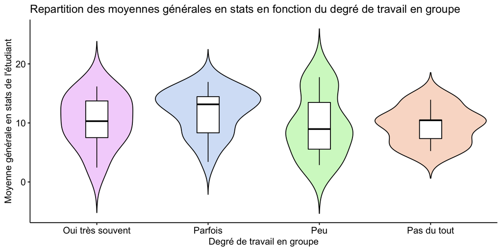

Effectuons un test unilatéral pour voir si la moyenne des moyennes générales en stats est significativement plus élevée pour la population travaillant en groupe :

| Egalité des Variances | Résultats du test de Student Moyenne de x | Résultats du test de Student Moyenne de y | Résultats du test de Student p.value du t.test |
| --- | --- | --- | --- |
| Oui | 11.5 | 9.58 | 0.06 |

La p-value est faible et inférieure au seuil de signification de 10%, on rejette donc l’hypothèse nulle et on conclut que les personnes travaillant en groupe ont une moyenne en statistiques supérieure à ceux qui ne travaillent pas en groupe.

### 6.2.4 Cas de la Micro

Voici une représentation de la distribution des notes en microéconomie en fonction du degré de travail en groupe :

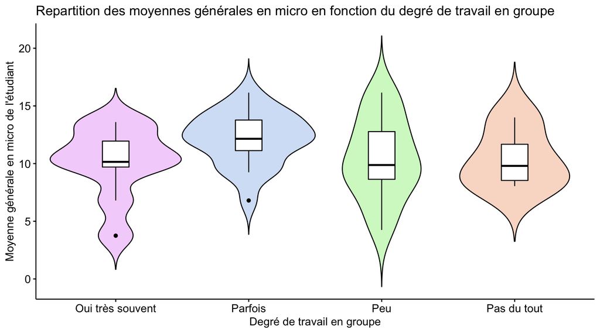

Les moyennes en microéconomie à l’année des étudiants en première année semblent plus élevées pour les élèves travaillant en groupe, réalisons un test pour confirmer ou réfuter cela :

| Egalité des Variances | Résultats du test de Student Moyenne de x | Résultats du test de Student Moyenne de y | Résultats du test de Student p.value du t.test |
| --- | --- | --- | --- |
| Oui | 11.51 | 10.43 | 0.11 |

On s’aperçoit que la p-value atteint presque le seuil de signification de 10% qui nous aurait permis de conclure que les élèves qui travaillent en groupe ont en général une moyenne supérieure aux autres. Mais ce n’est pas le cas donc nous conservons l’hypothèse nulle.

### 6.2.5 Cas de la macro

Voici une représentation de la distribution des notes en Macroéconomie en fonction du degré de travail en groupe :

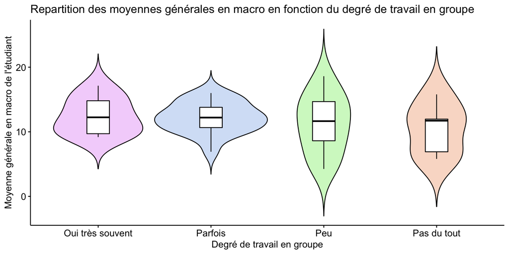

Les moyennes en macroéconomie des étudiants travaillant en groupe semblent plus concentrées autour de la moyenne et de la médiane dans cette matière, tandis que pour les autres étudiants les moyennes générales en macro sont plus dispersées. Voyons si les moyennes de ceux qui travaillent en groupe sont supérieures à celles de ceux qui ne travaillent jamais en groupe :

| Egalité des Variances | Résultats du test de Student Moyenne de x | Résultats du test de Student Moyenne de y | Résultats du test de Student p.value du t.test |
| --- | --- | --- | --- |
| Oui | 12.27 | 10.44 | 0.09 |

La p-value est inférieure au seuil de signification de 10% ce qui nous permet de conclure que la moyenne des moyennes générales en macroéconomie des étudiants travaillant en groupe est significativement supérieure à la moyenne des moyennes en macro de ceux qui ne travaillent jamais en groupe.

# 7 CONCLUSION

**Conclusion :**

Pour conclure, nous avons décidé d’étudier les effets du travail en groupe car il nous semble que c’est un élément essentiel à la fois pour nous étudiants mais aussi pour le corps enseignant. En effet il en va d’abord des préférences pour chaque étudiant à travailler plus ou moins en groupe mais il peut être intéressant de savoir si une tendance particulière se dégage précisément au niveau des notes des étudiants. Si celle-ci se vérifiait sur un très grand nombre de données, les professeurs pourraient alors inciter les élèves à travailler plus régulièrement en petit comité afin qu’ils partagent leurs connaissances et qu’ils s’entraident. De plus, ils pourraient dans ces cas là, rajouter quelques travaux en petits groupes dès la L1 et plus régulièrement en L2 et L3.

Pour ce qui est des résultats de nos travaux, nous nous sommes intéressés aux liens entre le travail en groupe et 4 autres variables, nous aurions pu établir plus de liens mais il nous semblait plus pertinent de nous focaliser sur un ensemble réduit mais déjà long d’analyse. Parmi les données recueillies des 146 personnes qui ont répondu aux questions sur le genre, l’année de licence et le fait d’aimer les cours, nous tirons de ces analyses qu’il n’y a une association statistiquement significative qu’entre le travail en groupe et le fait d’aimer ou non les cours. Nous n’avons pas pu conclure qu’il y avait une influence du degré de travail en groupe en fonction de l’année de licence ou en fonction du sexe de la personne.